# Classification Models to Detect the Presence of Heart Disease

Johan Setiawan

12/18/2021

# Introduction

## Goal

This is a dataset created to predict the presence of a heart disease. It was built with the purpose of helping ML researchers to build a model and find any other trends in heart data to predict certain cardiovascular events or find any clear indications of heart healths. The predicted output gives them a fair idea about whether a heart disease is present or absent in the patient.

## What we will do

We will use Logisitic Regression and KNN models on Heart Disease UCI data from Kaggle. We want to know the relationship among variables, especially between the target with other variables. We also want to predict the chance of someone having any heart disease using historical data. You can download the data here: https://www.kaggle.com/ronitf/heart-disease-uci

# Import Library

```r
library(dplyr)
library(ggplot2)
library(GGally)
library(performance)
library(MLmetrics)
library(rmdformats)
library(class)
library(caret)
```

# Data Preparation

## Read data

```r
heart <- read.csv("heart.csv")
rmarkdown::paged_table(heart)
```

| age | sex | cp | trestbps | chol | fbs | restecg | thalach | exang | oldpeak | slope | ca | thal | target |
| --- | --- | --- | --- | --- | --- | --- | --- | --- | --- | --- | --- | --- | --- |
| 63 | 1 | 3 | 145 | 233 | 1 | 0 | 150 | 0 | 2.3 | 0 | 0 | 1 | 1 |
| 37 | 1 | 2 | 130 | 250 | 0 | 1 | 187 | 0 | 3.5 | 0 | 0 | 2 | 1 |
| 41 | 0 | 1 | 130 | 204 | 0 | 0 | 172 | 0 | 1.4 | 2 | 0 | 2 | 1 |
| 56 | 1 | 1 | 120 | 236 | 0 | 1 | 178 | 0 | 0.8 | 2 | 0 | 2 | 1 |
| 57 | 0 | 0 | 120 | 354 | 0 | 1 | 163 | 1 | 0.6 | 2 | 0 | 2 | 1 |
| 57 | 1 | 0 | 140 | 192 | 0 | 1 | 148 | 0 | 0.4 | 1 | 0 | 1 | 1 |
| 56 | 0 | 1 | 140 | 294 | 0 | 0 | 153 | 0 | 1.3 | 1 | 0 | 2 | 1 |
| 44 | 1 | 1 | 120 | 263 | 0 | 1 | 173 | 0 | 0.0 | 2 | 0 | 3 | 1 |
| 52 | 1 | 2 | 172 | 199 | 1 | 1 | 162 | 0 | 0.5 | 2 | 0 | 3 | 1 |
| 57 | 1 | 2 | 150 | 168 | 0 | 1 | 174 | 0 | 1.6 | 2 | 0 | 2 | 1 |

[output cut: 293 more lines]

# Data Wrangling/Preprocessing

## Check for missing values

```r
heart %>%
  is.na() %>%
  colSums()/nrow(heart)
```

```
##      age      sex       cp trestbps     chol      fbs  restecg  thalach
##        0        0        0        0        0        0        0        0
##    exang  oldpeak    slope       ca     thal   target
##        0        0        0        0        0        0
```

No missing value, thus the data is well prepared.

## Check if there are any mismatched data type and change them if necessary

Changing them to the right data type will ease the data analytics and machine learning process.

```r
str(heart)
```

```
## 'data.frame':    303 obs. of  14 variables:
##  $ age     : int  63 37 41 56 57 57 56 44 52 57 ...
##  $ sex     : int  1 1 0 1 0 1 0 1 1 1 ...
##  $ cp      : int  3 2 1 1 0 0 1 1 2 2 ...
##  $ trestbps: int  145 130 130 120 120 140 140 120 172 150 ...
##  $ chol    : int  233 250 204 236 354 192 294 263 199 168 ...
##  $ fbs     : int  1 0 0 0 0 0 0 0 1 0 ...
##  $ restecg : int  0 1 0 1 1 1 0 1 1 1 ...
##  $ thalach : int  150 187 172 178 163 148 153 173 162 174 ...
##  $ exang   : int  0 0 0 0 1 0 0 0 0 0 ...
##  $ oldpeak : num  2.3 3.5 1.4 0.8 0.6 0.4 1.3 0 0.5 1.6 ...
##  $ slope   : int  0 0 2 2 2 1 1 2 2 2 ...
##  $ ca      : int  0 0 0 0 0 0 0 0 0 0 ...
##  $ thal    : int  1 2 2 2 2 1 2 3 3 2 ...
##  $ target  : int  1 1 1 1 1 1 1 1 1 1 ...
```

Looks like we have to change `sex`, `cp`, `fbs`, `exang` and `target` to Factor

## Change the respective columns to the right data types

```r
heart <- heart %>%
        mutate_at(vars(sex, cp, fbs, exang, target), as.factor)
str(heart)
```

```
## 'data.frame':    303 obs. of  14 variables:
##  $ age     : int  63 37 41 56 57 57 56 44 52 57 ...
##  $ sex     : Factor w/ 2 levels "0","1": 2 2 1 2 1 2 1 2 2 2 ...
##  $ cp      : Factor w/ 4 levels "0","1","2","3": 4 3 2 2 1 1 2 2 3 3 ...
##  $ trestbps: int  145 130 130 120 120 140 140 120 172 150 ...
##  $ chol    : int  233 250 204 236 354 192 294 263 199 168 ...
##  $ fbs     : Factor w/ 2 levels "0","1": 2 1 1 1 1 1 1 1 2 1 ...
##  $ restecg : int  0 1 0 1 1 1 0 1 1 1 ...
##  $ thalach : int  150 187 172 178 163 148 153 173 162 174 ...
##  $ exang   : Factor w/ 2 levels "0","1": 1 1 1 1 2 1 1 1 1 1 ...
##  $ oldpeak : num  2.3 3.5 1.4 0.8 0.6 0.4 1.3 0 0.5 1.6 ...
##  $ slope   : int  0 0 2 2 2 1 1 2 2 2 ...
##  $ ca      : int  0 0 0 0 0 0 0 0 0 0 ...
##  $ thal    : int  1 2 2 2 2 1 2 3 3 2 ...
##  $ target  : Factor w/ 2 levels "0","1": 2 2 2 2 2 2 2 2 2 2 ...
```

# Exploratory Data Analysis

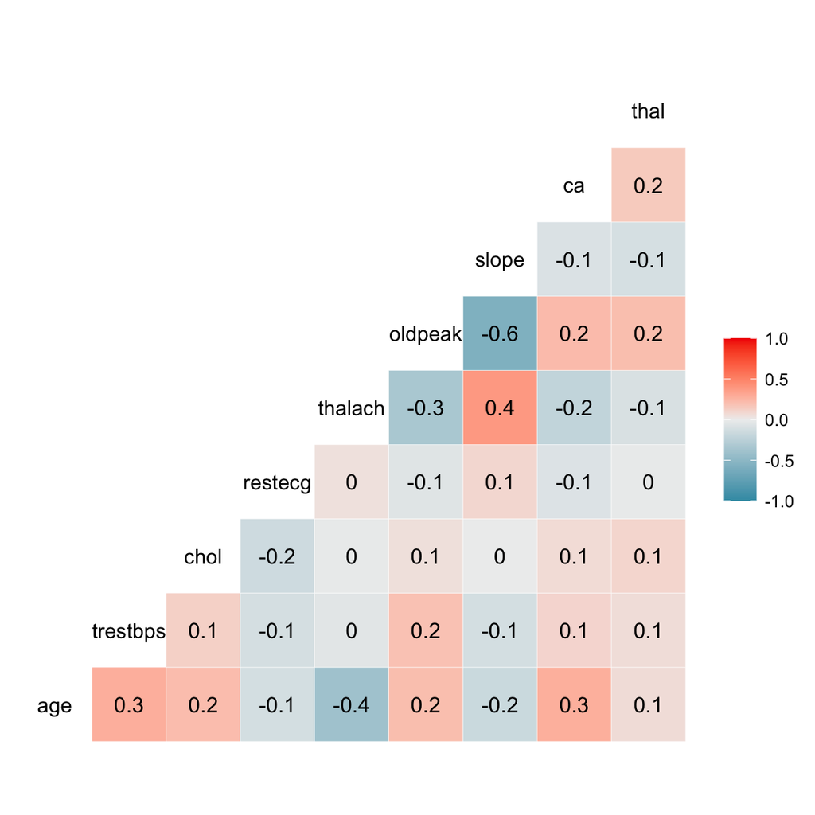

```r
ggcorr(heart, label = T, hjust = 0.5)
```

# Cross Validation

This step is necessary to prepare some “unseen” data for the ML model to determine its accuracy and performance We will use 75:25 proportion for this data

## Check if the target class proportion is balanced

```r
prop.table(table(heart$target))
```

```
##
##         0         1
## 0.4554455 0.5445545
```

It’s a very balanced dataset.

## Splitting the data into train and test sets

```r
set.seed(123)
index <- sample(nrow(heart), nrow(heart)*0.75)

data_train <- heart[index,]
data_test <- heart[-index,]
```

## Check target class proportion on the training data

```r
prop.table(table(data_train$target))
```

```
##
##         0         1
## 0.4537445 0.5462555
```

# Model Building

### Numeric variables scaling

To make the scale of all the numeric variables more uniform.

```r
# Take all the numeric variables
data_train_numeric <- data_train %>% select_if(is.numeric)
data_test_numeric <- data_test %>% select_if(is.numeric)

# Take all the non numeric variables
data_train_nn <- data_train %>% select(sex, cp, fbs, exang, target)
data_test_nn <- data_test %>% select(sex, cp, fbs, exang, target)

# Scale all the numeric variables
data_train_numeric_scaled <- scale(data_train_numeric)
data_test_numeric_scaled <- scale(data_test_numeric,
                           center = attr(data_train_numeric_scaled, "scaled:center"),
                           scale = attr(data_train_numeric_scaled, "scaled:scale"))

# Combining the numeric data with the non numeric data
data_train_new <- cbind(data_train_nn, data_train_numeric_scaled)
data_test_new <- cbind(data_test_nn, data_test_numeric_scaled)
```

### Separating target column from the rest of the dataset

```r
data_train_x <- data_train_new %>% select(-target)
data_test_x <- data_test_new %>% select(-target)

data_train_y <- data_train_new[,"target"]
data_test_y <- data_test_new[,"target"]
```

## Logistic Regression model

```r
lg_model <- glm(formula = target~.,
                   family="binomial",
                   data = data_train_new)
```

## KNN model

### Determine the number of class in the target variable

```r
unique(data_train_new$target)
```

```
## [1] 0 1
## Levels: 0 1
```

Since there are 2 (even number) classes for the target variable, we have to use odd number for the K in the KNN model

### Determine the K for KNN model

```r
sqrt(nrow(data_train_new))
```

```
## [1] 15.06652
```

```r
knn_model <- knn(train = data_train_x,
                     test = data_test_x,
                     cl = data_train_y,
                     k = 15)
```

# Model Evaluation

Evaluation of the model will be done with confusion matrix. Confusion matrix is a table that shows four different category: True Positive, True Negative, False Positive, and False Negative. The performance will be the Accuracy, Sensitivity/Recall, Specificity, and Precision (Saito and Rehmsmeier, 2015). Accuracy measures how many of our data is correctly predicted. Sensitivity measures out of all positive outcome, how many are correctly predicted. Specificty measure how many negative outcome is correctly predicted. Precision measures how many of our positive prediction is correct.

In this case, we will be evaluating our model using Recall since we emphasize more on having lesser false negative than false positive.

## Logistic regression confusion matrix

Making a prediction using logistic regression model

```r
data_test_new$pred_Risk <- predict(object = lg_model,
        newdata = data_test_new,
        type = "response")

data_test_new$pred_Label <- ifelse(data_test_new$pred_Risk > 0.5 , yes = "1", no = "0")
data_test_new$pred_Label <- as.factor(data_test_new$pred_Label)
```

```r
confusionMatrix(data = as.factor(data_test_new$pred_Label),
                reference = as.factor(data_test_y),
                positive = "1")
```

```
## Confusion Matrix and Statistics
##
##           Reference
## Prediction  0  1
##          0 25  2
##          1 10 39
##
##                Accuracy : 0.8421
##                  95% CI : (0.7404, 0.9157)
##     No Information Rate : 0.5395
##     P-Value [Acc > NIR] : 2.51e-08
##
##                   Kappa : 0.6768
##
##  Mcnemar's Test P-Value : 0.04331
##
##             Sensitivity : 0.9512
##             Specificity : 0.7143
##          Pos Pred Value : 0.7959
##          Neg Pred Value : 0.9259
##              Prevalence : 0.5395
##          Detection Rate : 0.5132
##    Detection Prevalence : 0.6447
##       Balanced Accuracy : 0.8328
##
##        'Positive' Class : 1
##
```

## KNN confusion matrix

```r
confusionMatrix(data = as.factor(knn_model),
                reference = as.factor(data_test_y),
                positive = "1")
```

```
## Confusion Matrix and Statistics
##
##           Reference
## Prediction  0  1
##          0 23  1
##          1 12 40
##
##                Accuracy : 0.8289
##                  95% CI : (0.7253, 0.9057)
##     No Information Rate : 0.5395
##     P-Value [Acc > NIR] : 1.083e-07
##
##                   Kappa : 0.6476
##
##  Mcnemar's Test P-Value : 0.005546
##
##             Sensitivity : 0.9756
##             Specificity : 0.6571
##          Pos Pred Value : 0.7692
##          Neg Pred Value : 0.9583
##              Prevalence : 0.5395
##          Detection Rate : 0.5263
##    Detection Prevalence : 0.6842
##       Balanced Accuracy : 0.8164
##
##        'Positive' Class : 1
##
```

# Model fine-tuning

## Logistic regression model fine-tuning

### Using step-wise regression to find the best predictors

```r
lg_tuned <- step(lg_model, direction = "backward", trace = F)
```

### Making a prediction using fine-tuned logistic regression model

```r
data_test_new$pred_Risk <- predict(object = lg_tuned,
        newdata = data_test_new,
        type = "response")

data_test_new$pred_Label <- ifelse(data_test_new$pred_Risk > 0.5 , yes = "1", no = "0")
data_test_new$pred_Label <- as.factor(data_test_new$pred_Label)
```

### Logistic regression model confusion matrix

```r
confusionMatrix(data = as.factor(data_test_new$pred_Label),
                reference = as.factor(data_test_y),
                positive = "1")
```

```
## Confusion Matrix and Statistics
##
##           Reference
## Prediction  0  1
##          0 25  3
##          1 10 38
##
##                Accuracy : 0.8289
##                  95% CI : (0.7253, 0.9057)
##     No Information Rate : 0.5395
##     P-Value [Acc > NIR] : 1.083e-07
##
##                   Kappa : 0.6506
##
##  Mcnemar's Test P-Value : 0.09609
##
##             Sensitivity : 0.9268
##             Specificity : 0.7143
##          Pos Pred Value : 0.7917
##          Neg Pred Value : 0.8929
##              Prevalence : 0.5395
##          Detection Rate : 0.5000
##    Detection Prevalence : 0.6316
##       Balanced Accuracy : 0.8206
##
##        'Positive' Class : 1
##
```

## KNN model fine-tuning

### Changing the K value of KNN

```r
knn_tuned <- knn(train = data_train_x,
                test = data_test_x,
                cl = data_train_y,
                k = 17)
```

### KNN model confusion matrix

```r
confusionMatrix(data = as.factor(knn_tuned),
                reference = as.factor(data_test_y),
                positive = "1")
```

```
## Confusion Matrix and Statistics
##
##           Reference
## Prediction  0  1
##          0 23  1
##          1 12 40
##
##                Accuracy : 0.8289
##                  95% CI : (0.7253, 0.9057)
##     No Information Rate : 0.5395
##     P-Value [Acc > NIR] : 1.083e-07
##
##                   Kappa : 0.6476
##
##  Mcnemar's Test P-Value : 0.005546
##
##             Sensitivity : 0.9756
##             Specificity : 0.6571
##          Pos Pred Value : 0.7692
##          Neg Pred Value : 0.9583
##              Prevalence : 0.5395
##          Detection Rate : 0.5263
##    Detection Prevalence : 0.6842
##       Balanced Accuracy : 0.8164
##
##        'Positive' Class : 1
##
```

# Conclusion

- Since we are looking for the `recall/sensitivity`, KNN model performed better in this dataset compared to the logistic regression model.
- Original logistic regression model performed better on the accuracy and recall compared to the fine-tuned one.

In the medical world, I think it is really crucial to have a model that reduces the false detection of a healthy person when they are actually not, especially in the cardiovascular world as the heart works as one of our core organs. Thus, giving false treatment to the actually healthy group of people might be less dangerous.

# Reference

Hungarian Institute of Cardiology. Budapest: Andras Janosi, M.D. University Hospital, Zurich, Switzerland: William Steinbrunn, M.D. University Hospital, Basel, Switzerland: Matthias Pfisterer, M.D. V.A. Medical Center, Long Beach and Cleveland Clinic Foundation: Robert Detrano, M.D., Ph.D. David W. Aha (aha ‘@’ ics.uci.edu) (714) 856-8779